# hw5

**Q1**

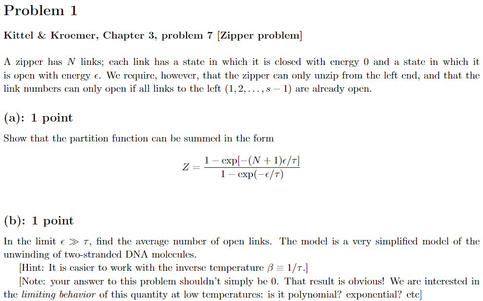

(a)

$$ Z = \sum_{s} e^{-\epsilon_s/\tau} $$

This problem is just a fancy way of saying there are N+1 states with energy 0 to $\epsilon \times N$

$$ Z = 1 + e^{-\epsilon/\tau} + e^{-2\epsilon/\tau} +\dots + e^{-N \epsilon /\tau} \\ \hspace{1.2cm} -Ze^{-\epsilon/\tau} = -e^{-\epsilon/\tau} - e^{-2\epsilon/\tau} - \dots - e^{-N \epsilon /\tau} - e^{-(N+1)\epsilon/\tau} \\ Z - Ze^{-\epsilon/\tau} = 1 - e^{-(N+1)\epsilon/\tau} \\ Z \left(1-e^{-\epsilon/\tau}\right) = 1 - e^{-(N+1)\epsilon/\tau} \\ Z = \frac{1 - e^{-(N+1)\epsilon/\tau}}{1-e^{-\epsilon/\tau}} $$

Yes I did align #1 and #2 on purpose

(b) $\epsilon \gg \tau \rightarrow \epsilon \beta \gg 1$

$$ Z = \frac{1 - e^{-(N+1)\epsilon\beta}}{1-e^{-\epsilon \beta}} \\ \ln Z = \ln\left(1 - e^{-(N+1)\epsilon\beta}\right) - \ln\left(1-e^{-\epsilon \beta}\right) \\ U = - \frac{\partial \ln Z}{\partial \beta} \\ $$

```python
import sympy as sym
from sympy import ln, exp, oo

epsilon, beta, N = sym.symbols('epsilon beta N')

lnZ = ln( ( 1 - exp(-(N+1)*epsilon*beta) ) / (1 - exp(-epsilon*beta) ) )
sym.diff(-lnZ, beta)
```

$\displaystyle - \frac{\left(1 - e^{- \beta \epsilon}\right) \left(- \frac{\epsilon \left(- N - 1\right) e^{\beta \epsilon \left(- N - 1\right)}}{1 - e^{- \beta \epsilon}} - \frac{\epsilon \left(1 - e^{\beta \epsilon \left(- N - 1\right)}\right) e^{- \beta \epsilon}}{\left(1 - e^{- \beta \epsilon}\right)^{2}}\right)}{1 - e^{\beta \epsilon \left(- N - 1\right)}}$

Note that we want the average number $n$ of open links, which has energy $\epsilon n$

**Q2**

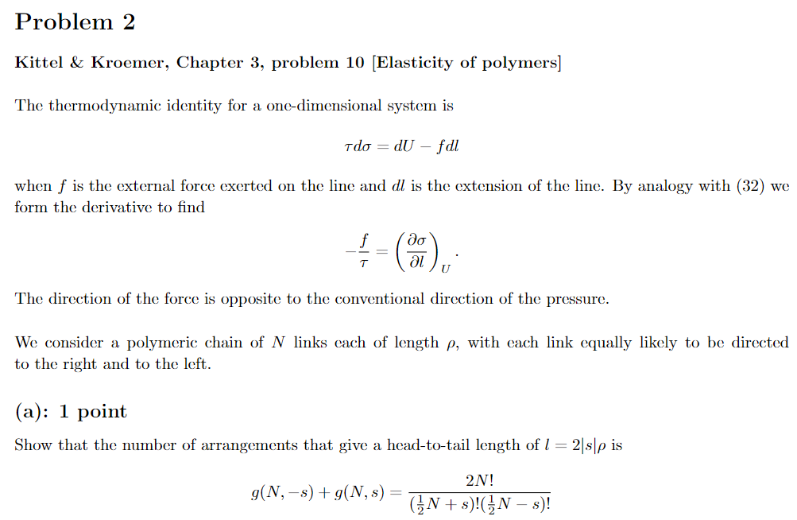

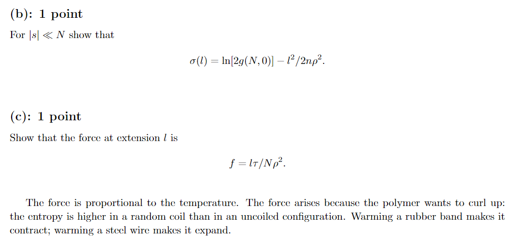

This is a sort of change in volume, with $f$ instead of $p$ and $\delta l$ instead of $\delta V$ in 1D.

$$ \tau d \sigma = dU + p dV \\ \Downarrow \\ \tau d \sigma = dU - f dl $$

We might have to re-derive the free energy $F$, but we'll get there later.

(a) Our system is quantized/discrete, with N links each left or right facing, and a total of $2^N$ possible states. Aka binomial! $s$ is the spin (flip) excess $s =(s_\leftarrow - s_\rightarrow)/2$

For N=3 the possible arrangements are: $$ \leftarrow \leftarrow \leftarrow l=3\rho \quad \rightarrow \rightarrow \leftarrow l=\rho\\ \leftarrow \leftarrow \rightarrow l=\rho \quad \rightarrow \leftarrow \rightarrow l=\rho\\ \leftarrow \rightarrow \leftarrow l=\rho \quad \leftarrow \rightarrow \rightarrow l=\rho\\ \rightarrow \leftarrow \leftarrow l=\rho \quad \rightarrow \rightarrow \rightarrow l=3\rho\\ $$

Okay, quick sanity check works out. Since this is binomial we can use our spin-excess multiplicity formula.

The number of states with flip excess $s$ is

$$ g(N,s) = \frac{N!}{(N/2 + s)!(N/2-s)!} $$

Since $l = 2|s|\rho = 2|-s|\rho$, negative and positive excess have the same length

$$ g(l) = g(N,|s|) = g(N,-s)+ g(N,s) = 2g(N,s) $$

(b) $\sigma(l) = \ln g(l)$, also note $s = \frac{l}{2 \rho}$

Using our approximation $g(N,s) \approx 2^N e^{-2s^2/N}$, we have

$$ g(l) = 2 g(N,s) \approx 2 g(N,0) e^{-2s^2/N} \\ \ln g(l) \approx \ln(2 g(N,0) e^{-2s^2/N}) = \ln(2 g(N,0)) + \ln(e^{-2s^2/N}) \\ = \ln(2 g(N,0)) -2s^2/N \\ = \ln(2 g(N,0)) -l^2/2 N\rho^2 $$

(c) $f = -\tau \frac{\partial \sigma}{\partial l}_U$

$$ \frac{\partial \sigma}{\partial l} \left(- \frac{l^2}{2 N \rho^2} \right) = -\frac{l}{N \rho^2} \\ f = -\tau \left(-\frac{l}{N \rho^2} \right) = \frac{l\tau}{N \rho^2} $$

**Q3**

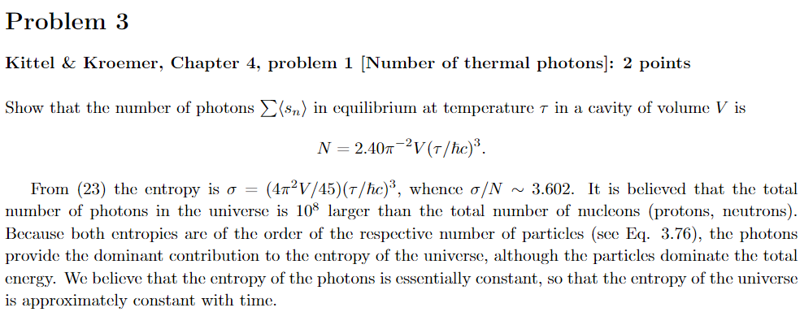

$$ N = \sum \langle s_n \rangle $$ There is a walkthrough of $U = \sum \langle \epsilon_n \rangle$ in the book, we only need to replace $\langle \epsilon_n \rangle$ with $\langle s \rangle = \frac{\langle \epsilon_n \rangle}{\hbar \omega}$ $$ \langle s(\omega) \rangle = \frac{1}{e^{\hbar \omega / \tau}-1} \\ \sum \langle s_n \rangle = \sum\frac{1}{e^{\hbar \omega_n / \tau}-1} \\ $$

We'll convert to integral form $$ \sum_n \left(\right) = \frac{2}{8} \int_0^\infty 4 \pi n^2 dn \left(\right) \\ \omega_n = n \pi c / L \\ \sum\frac{1}{e^{\hbar \omega_n / \tau}-1} = \int_0^\infty \pi n^2 dn \left(\frac{1}{e^{\hbar n \pi c / \tau L }-1} \right) = \dots $$

We'll use $x= \frac{\hbar n \pi c}{\tau L},\ n = \frac{x \tau L}{\hbar \pi c} $

$$ \frac{dx}{dn} = \frac{\hbar \pi c}{\tau L} \\ dn = dx\frac{\tau L}{\hbar \pi c} \\ $$

$$ \int_0^\infty \pi n^2 dn \left(\frac{1}{e^{\hbar n \pi c / \tau L }-1} \right) = \pi \left(\frac{\tau L}{\hbar \pi c} \right)^2 \frac{\tau L}{\hbar \pi c}\int_0^\infty dx \left(\frac{x^2}{e^{x}-1} \right) \\ = \frac{\pi}{\pi^3} V (\tau / \hbar c)^{3} (2.40411) \\ = 2.40 \pi^{-2} V (\tau /\hbar c)^3 = N $$

**Q4**

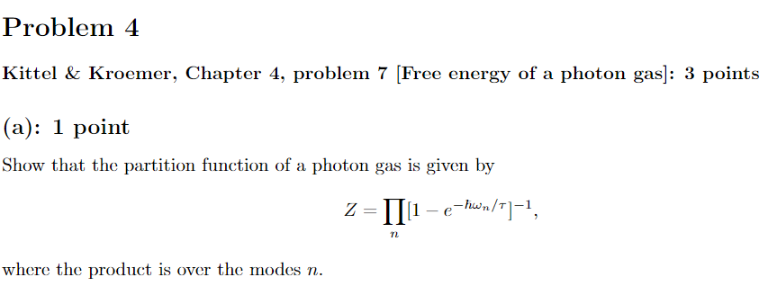

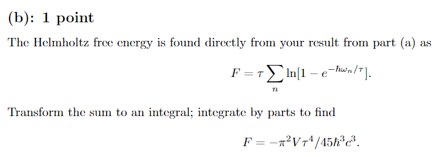

(a) The partition function for a photon of frequency $\omega_n$ is

$$ Z = \frac{1}{1-e^{-\hbar \omega_n/\tau}} \hspace{3cm} (3), \text{ Kittel chp } 4 $$

Each one has their own partition function, so together (as shown in hw#3), we have

$$ Z_{gas} = \prod_n Z(n) = \prod_n \frac{1}{1-e^{-\hbar \omega_n/\tau}} $$

(b)

$$ F = \tau \sum_n \ln \left[ 1 - e^{-\hbar \omega_n / \tau}\right] $$

This summation becomes the integral

$$ F = \tau \pi \int_0^\infty \ln \left( 1-e^{-\hbar \omega_n / \tau} \right) n^2 dn $$

$$ x = \hbar \omega_n / \tau = \hbar n \pi c / L \tau n = \frac{ x \tau L}{\hbar \pi c} \\ dn = dx\frac{ \tau L}{\hbar \pi c} \\ F = \tau \pi \left(\frac{ \tau L}{\hbar \pi c}\right)^3 \int_0^\infty \ln \left( 1- e^{-x} \right) x^2 dx \\ $$ Integration by parts? That sounds like work! I don't want to do work I want to graduate! I did ask my friend what this comes out to though:

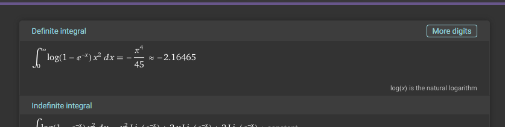

$$ F=\frac{\tau^4}{\pi^2}V\left(\frac{1}{\hbar c}\right)^3 \left(-\frac{\pi^4}{45} \right) = -\pi^2 V \tau^4 / 45 \hbar^3 c^3 $$

```python
x = sym.symbols('x')
integrand = ln(1- exp(-x)) * x**2

sym.integrate(integrand, (x, 0, oo))
```

$\displaystyle - \frac{\int\limits_{0}^{\infty} \frac{x^{3}}{e^{x} - 1}\, dx}{3}$